# Tutorial of Mean Cumulative Count (MCC)

Grace Zhou

2025-02-19

# Introduction

This document demonstrates how to use the `MY.MCC` function to achieve MCC within a specific time period. Additionally, the functions `at.risk`, and `mcc.plot` are included to display MCC results in a plot with an at-risk table.

# R version

```r
R.Version()
```

```
## $platform
## [1] "x86_64-w64-mingw32"
##
## $arch
## [1] "x86_64"
##
## $os
## [1] "mingw32"
##
## $crt
## [1] "ucrt"
##
## $system
## [1] "x86_64, mingw32"
##
## $status
## [1] ""
##
## $major
## [1] "4"
##
## $minor
## [1] "4.0"
##
## $year
## [1] "2024"
##
## $month
## [1] "04"
##
## $day
## [1] "24"
##
## $`svn rev`
## [1] "86474"
##
## $language
## [1] "R"
##
## $version.string
## [1] "R version 4.4.0 (2024-04-24 ucrt)"
##
## $nickname
## [1] "Puppy Cup"
```

# Install package

```r
install.packages('dplyr')  #Data management
install.packages('cmprsk') #CIF for right censoring only + competing risk
install.packages('mstate') #CIF for left truncation and/or right censoring + competing risk
```

# Load function

First, load the necessary libraries and source the function.

```r
library(dplyr) #v1.1.4
library(cmprsk) #2.2-12
library(mstate) #0.3.3
source('MY_MCC.r') #https://github.com/GraceChenZhou/Mean-Cumulative-Count.git
```

# Using function

```r
#' MY.MCC
#'
#' Estimate Mean Cumulative Count with 95% Confidence Interval
#'
#' @param id variable name that identifies subjects
#' @param time variable name that reflects survival time
#' @param status variable name that indicates status: 0=censored, 1=event, 2=competing risk
#' @param Tstart a vector of entry time in the presence of left-truncation; a vector or a number of 0 indicates the absence of left-truncation
#' @param ci logical value: if TRUE, 95% boostrap confidence interval is returned
#' @param niter a number specifying the number of iteration in the boostrap percentile method
#' @return output as a data frame

MY.MCC(id, time, status, Tstart, ci=TRUE, niter=1000)
```

## Example 1

We will create sample data as described in Dong et al. (2015) and demonstrate the usage of the function to achieve the MCC results.

In the illustrative example, five participants were enrolled at the beginning. Subject 1 was alive at the end of the study and was considered censored at t8. Subject 2 was lost to follow-up at t1 and treated as censored. Subject 3 died from a competing-risk event at t5. Subject 4 experienced the event of interest three times (at t2, t6, and t7). Subject 5 experienced the event of interest once at t3 and died at t4.

```r
example.data <- data.frame(id=c(1,2,3,4,4,4,5,5),
                           time=c(8,1,5,2,6,7,3,4),
                           status=c(0,0,2,1,1,1,1,2))

example.data
```

```
##   id time status
## 1  1    8      0
## 2  2    1      0
## 3  3    5      2
## 4  4    2      1
## 5  4    6      1
## 6  4    7      1
## 7  5    3      1
## 8  5    4      2
```

We can specify the subject `id`, survival `time`, and `status` (0 = censored, 1 = event, 2 = competing risk) in the function. Because there is no left-truncation issue, `Tstart` is assigned a value of 0. Additionally, setting `ci = FALSE` prevents the calculation of the confidence interval for MCC.

```r
mcc.result <- MY.MCC(id=example.data$id,time=example.data$time,
                  status=example.data$status,Tstart=0,ci=FALSE)
```

The returned output is a data frame with columns: MCC and time. These results match the MCC results presented in the paper.

```r
mcc.result
```

```
##    MCC time
## 1 0.00    1
## 2 0.25    2
## 3 0.50    3
## 4 0.50    4
## 5 0.50    5
## 6 0.75    6
## 7 1.00    7
## 8 1.00    8
```

## Example 2

In this example, we will demonstrate how to present MCC results in a plot for a manuscript. The data example is a subset data comes from a Childhood Cancer Survivor Study (CCSS) project.

This data set contains 500 Survivors and 500 Siblings, including their survival age (e.g., T_AGE) and STATUS (0 = censored, 1 = event, 2 = competing risk). Specifically, the survivors’ data are left-truncated, as those who died before study entry are not included in the analysis. There is no left-truncation issue for siblings.

```r
example.data2 <- read.csv('dataset.csv')
str(example.data2)
```

```
## 'data.frame':    1055 obs. of  5 variables:
##  $ ID     : int  1 2 3 4 5 6 7 8 9 10 ...
##  $ GROUP  : chr  "Survivors" "Survivors" "Survivors" "Survivors" ...
##  $ T_AGE  : num  56.3 64 27.4 49 42.3 ...
##  $ STATUS : int  0 0 0 0 0 0 2 0 0 0 ...
##  $ A_ENTRY: int  20 24 23 20 18 15 16 10 25 12 ...
```

We can estimate MCC with a 95% confidence interval for survivors and siblings, respectively.

```r
##Filter data for survivors and siblings
my.surv <- example.data2 %>% filter(GROUP=='Survivors')
my.sib <- example.data2 %>% filter(GROUP=='Siblings')

##Calculate MCC for survivors
cat('Calculate MCC for survivors: \n')
```

```
## Calculate MCC for survivors:
```

```r
start.time <- Sys.time()
my.mcc.surv <- MY.MCC(id=my.surv$ID,
                      time=my.surv$T_AGE,
                      status=my.surv$STATUS,
                      Tstart=my.surv$A_ENTRY,
                      ci=TRUE, niter=1000)
```

```
## iteration: 100
## iteration: 200
## iteration: 300
## iteration: 400
## iteration: 500
## iteration: 600
## iteration: 700
## iteration: 800
## iteration: 900
## iteration: 1000
```

```r
end.time <- Sys.time()

print(round(end.time - start.time, 2))
```

```
## Time difference of 2.58 mins
```

```r
##Calculate MCC for survivors
cat('Calculate MCC for siblings: \n')
```

```
## Calculate MCC for siblings:
```

```r
start.time <- Sys.time()
my.mcc.sib <- MY.MCC(id=my.sib$ID,
                      time=my.sib$T_AGE,
                      status=my.sib$STATUS,
                      Tstart=my.sib$A_ENTRY,
                      ci=TRUE, niter=1000)
```

```
## iteration: 100
## iteration: 200
## iteration: 300
## iteration: 400
## iteration: 500
## iteration: 600
## iteration: 700
## iteration: 800
## iteration: 900
## iteration: 1000
```

```r
end.time <- Sys.time()
print(round(end.time - start.time, 2))
```

```
## Time difference of 58.23 secs
```

Combine to obtain the final MCC output.

```r
##Add group labels to MCC results
my.mcc.surv2 <- my.mcc.surv %>% mutate(Group='Survivors')
my.mcc.sib2 <- my.mcc.sib %>% mutate(Group='Siblings')

##Final MCC Output
my.mcc.output <- rbind(my.mcc.surv2,my.mcc.sib2)

head(my.mcc.output)
```

```
## # A tibble: 6 × 5
##    time    MCC   lci    uci Group
##   <dbl>  <dbl> <dbl>  <dbl> <chr>
## 1  9.34 0          0 0      Survivors
## 2 12    0.0256     0 0.0658 Survivors
## 3 12.4  0.0256     0 0.0658 Survivors
## 4 12.8  0.0256     0 0.0658 Survivors
## 5 13    0.0348     0 0.0791 Survivors
## 6 13.1  0.0348     0 0.0791 Survivors
```

In the following step, we aim to demonstrate how to plot MCC by adding a number at risk table. First, we define a function to calculate the number at risk, noting that individuals who encounter the event of interest are still at risk for another occurrence of the event.

```r
#' at.risk
#'
#' Table of At Risk/Censored (Events)
#'
#' @param id variable name that identifies subjects
#' @param time variable name that reflects survival time
#' @param status variable name that indicates status: 0=censored, 1=event, 2=competing risk
#' @param grp variable name that specifies groups
#' @param time.len a number that addresses time length
#' @return output as a data frame

at.risk <- function(id,time,status,grp,time.len){

  indata <- data.frame(id=id,
                       time=time,
                       status=status,
                       grp=grp)

  #select the last record for each id
  indata2 <- indata %>% arrange(grp,id,-time) %>% group_by(grp,id) %>% slice(1) %>% ungroup()
  end.time <- max(indata$time,na.rm=T)

  #select out censoring and competing risk
  indata3 <- indata2 %>% filter(time!=end.time & status!=1) %>% mutate(temp=1)

  #calculate risk sets by time cutoff
  risksets <- with(na.omit(indata3[, Hmisc::Cs(time,temp,grp)]),
                   table(grp,cut(time, seq(0, end.time, by = time.len),right=F)))

  #calculate number of individuals initially at risk
  init.num <- indata2 %>% group_by(grp) %>% tally()

  #calculate number at risk at each time cutoff
  n.at.risk <- sapply(1:nrow(risksets),
                      function(i) Reduce('-',risksets[i,],
                                         init=init.num$n[i],
                                         accumulate=T))

  colnames(n.at.risk) <- init.num$grp

  #calculate censor at each time cutoff
  censor.dt <- indata2 %>% filter(time!=end.time & status==0) %>% mutate(temp=1)
  censorsets <- with(na.omit(censor.dt[, Hmisc::Cs(time,temp,grp)]),
                     table(grp,cut(time, seq(0, end.time, by = time.len))))
  n.censor <- sapply(1:nrow(censorsets),
                     function(i) Reduce('+',censorsets[i,],
                                        init=0,
                                        accumulate=T))

  colnames(n.censor) <- init.num$grp

  #calculate event at each time cutoff
  event.dt <- indata %>% filter(status==1) %>% mutate(temp=1)
  eventsets <- with(na.omit(event.dt[, Hmisc::Cs(time,temp,grp)]),
                    table(grp,cut(time, seq(0, end.time, by = time.len))))
  n.event <- sapply(1:nrow(eventsets),
                    function(i) Reduce('+',eventsets[i,],
                                       init=0,
                                       accumulate=T))
  colnames(n.event) <- init.num$grp

  #output a data frame
  name.grp <- as.character(unique(init.num$grp))

  output.list <- list()

  for (i in name.grp){

    ith.grp <- data.frame(n.at.risk=n.at.risk[,i],
                          n.censor=n.censor[,i],
                          n.event=n.event[,i]) %>%
      reframe(i=paste0(n.at.risk,'/',n.censor,'(',n.event,')'))
    names(ith.grp) <- i

    output.list[[i]] <- ith.grp

  }

  output.dt <- do.call(cbind,output.list) %>% mutate(time=seq(0, end.time, by = time.len))

  return(output.dt)
}
```

We can assign variables from the input data and specify a time length, such as 10 years. This result will be used in the subsequent plot function.

```r
risk.df <- at.risk(id=example.data2$ID,
                time=example.data2$T_AGE,
                status=example.data2$STATUS,
                grp=example.data2$GROUP,
                time.len=10)

risk.df
```

```
##     Siblings   Survivors time
## 1   500/0(0)    500/0(0)    0
## 2   500/0(0)    499/0(0)   10
## 3  477/23(2)   466/8(17)   20
## 4 374/124(3)  367/62(27)   30
## 5 256/241(4) 207/210(37)   40
## 6 119/375(6)  78/334(45)   50
## 7  30/464(7)  12/398(49)   60
```

To plot efficiently, we define a plot function. Users can input the mcc output generated from the `MY.MCC` function and the result from the `at.risk` function, specifying the labels for the x-axis, y-axis, and the title for the plot.

```r
#' mcc.plot
#'
#' MCC plot with at risk table
#'
#' @param mcc.out mcc output from MY.MCC function
#' @param risk.df risk output from at.risk function
#' @param xlab label for x-axis
#' @param ylab label for y-axis
#' @param title plot title
#' @return plot object

mcc.plot <- function(mcc.out,risk.df,xlab,ylab,title,...){

  plot(c(min(mcc.out$time),max(mcc.out$time)),
       c(min(mcc.out$lci),
         max(mcc.out$uci)),
       xlab="", ylab="",type = "n")

  title(xlab = xlab, cex.lab=0.8, font.lab=2, line=2.5)
  title(ylab = ylab, cex.lab=0.6, font.lab=2, line=2.5)
  title(title,cex.lab=0.8)

  groups <- unique(mcc.out$Group)
  mcc.grp1 <- mcc.out %>% filter(Group==groups[1])
  mcc.grp2 <- mcc.out %>% filter(Group==groups[2])

  lines(mcc.grp1$time, mcc.grp1$MCC, type="s",lwd=3,col='#F8766D',lty=1) #type='s' means Stairs
  lines(mcc.grp2$time, mcc.grp2$MCC, type="s",lwd=3,col="#00BFC4",lty=1) #type='s' means Stairs

  #To obtain confidence interval in the style of stair, we need to cut time into small intervals

  dummy <- data.frame(time=seq(min(mcc.grp1$time),max(mcc.grp1$time),by=0.01))
  mcc.grp1.2 <- mcc.grp1 %>% full_join(dummy,by='time') %>% arrange(time) %>%
    mutate_at(.vars=-c(1),zoo::na.locf)

  polygon(c(mcc.grp1.2$time, rev(mcc.grp1.2$time)), c(mcc.grp1.2$uci, rev(mcc.grp1.2$lci)),
          col = scales::alpha('#F8766D', 0.5), border = NA)

  dummy <- data.frame(time=seq(min(mcc.grp2$time),max(mcc.grp2$time),by=0.01))
  mcc.grp2.2 <- mcc.grp2 %>% full_join(dummy,by='time') %>% arrange(time) %>%
    mutate_at(.vars=-c(1),zoo::na.locf)

  polygon(c(mcc.grp2.2$time, rev(mcc.grp2.2$time)), c(mcc.grp2.2$uci, rev(mcc.grp2.2$lci)),
          col = scales::alpha("#00BFC4", 0.5), border = NA)

  legend("topleft", c(groups[1], groups[2]), col=c('#F8766D',"#00BFC4"),
         inset=0.05, lty=1:1,lwd=2, cex=0.8, bty="n")

  mtext(side=1, text="At Risk/Censored (Event)", adj=0, line=2.0, cex=0.8, font=2)

  axis(side=1,at=risk.df$time,label=risk.df[,groups[1]],las=1,tick=FALSE,line=2.2,lwd=2.5,cex.axis=0.6,font=2)
  mtext(side=1, text=groups[1],adj=-0.1, line=3.17,cex=0.6,font=2)

  axis(side=1,at=risk.df$time,label=risk.df[,groups[2]],las=1,tick=FALSE,line=3,lwd=2.5,cex.axis=0.6,font=2)
  mtext(side=1, text=groups[2],adj=-0.1,line=4,cex=0.6,font=2)

}
```

The plot generated by the `mcc.plot` function illustrates the comparison of MCC between survivors and siblings over time, accounting for left-truncation and competing risks.

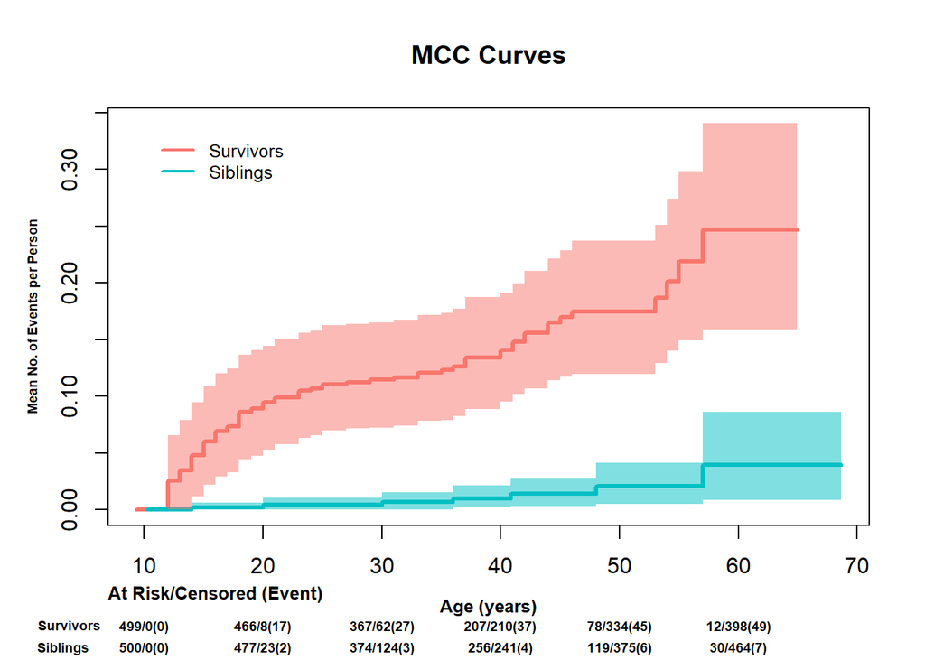

```r
mcc.plot(mcc.out=my.mcc.output, risk.df=risk.df,
         xlab='Age (years)', ylab='Mean No. of Events per Person', title='MCC Curves')
```

# Conclusion

In this document, we have demonstrated how to use the `MY.MCC` function to achieve MCC within a specific time period and how to visualize the results using additional functions. By following the steps outlined, users can effectively analyze and present MCC results, including confidence intervals and at-risk tables. This approach provides a proper method for handling left-truncated data with competing risks in a survival analysis context and fills the gap by offering a solution for estimating MCC and plotting it with at-risk table, which is not available in any existing R functions.

# References

Geskus RB. Cause-specific cumulative incidence estimation and the fine and gray model under both left truncation and right censoring. Biometrics. 2011 Mar;67(1):39-49. doi: 10.1111/j.1541-0420.2010.01420.x. PMID: 20377575.

Dong H, Robison LL, Leisenring WM, Martin LJ, Armstrong GT, Yasui Y. Estimating the burden of recurrent events in the presence of competing risks: the method of mean cumulative count. Am J Epidemiol. 2015 Apr 1;181(7):532-40. d. Epub 2015 Feb 17. PMID: 25693770; PMCID: PMC4371763. doi: 10.1093/aje/kwu289